# Final Project Ideas

October 31, 2020

## Project Data-sets

Possible Data Sets and Problems

| Data Sets | Problem Description |
| --- | --- |
| Prostate Cancer Data Set | Large-scale Simultaneous Hypothesis Testing |
| Exit Poll Data 2016 and 2020 | Analyze Associations |

## Today

1. This intro will show you how to read the two data-sets and get basic summary. It will also suggest some of the analysis that you can perform.
2. You can use one of the methods taught in class (or try new methods - it’s up to you (and your team)).
3. You do not need to present your work. Only submit a well-written report.

## Project 1: Multiple Nonparametric Testing: Gene Expression Data

## Project 1: Analysing Genomic Data

- Possible Inferential Goals:
1. Visualize the data: e.g. compare the baseline expression values between two groups.
2. Carry out Multiple testing.
3. We can carry out \(p\) simultaneous tests for each of the variables:

## Large Scale Testing

- Suppose for the \(i^{th}\) variable \(x_{i}\) the two group means are \(\theta_{i,1}\) and \(\theta_{i,2}\). \[ H_{0i}: \theta_{i,1} = \theta_{i,2} \text{ vs. } H_{1i}: \theta_{i,1} \neq \theta_{i,2} \]
- If \(H_{0i}\) is true, the group means \(\bar{x}_{i,1}\) and \(\bar{x}_{i,2}\) should be close.
- We can do an independent samples t-test for each of the \(p\) variables.
- **Multiplicity** !!

## Example with Simulated Data

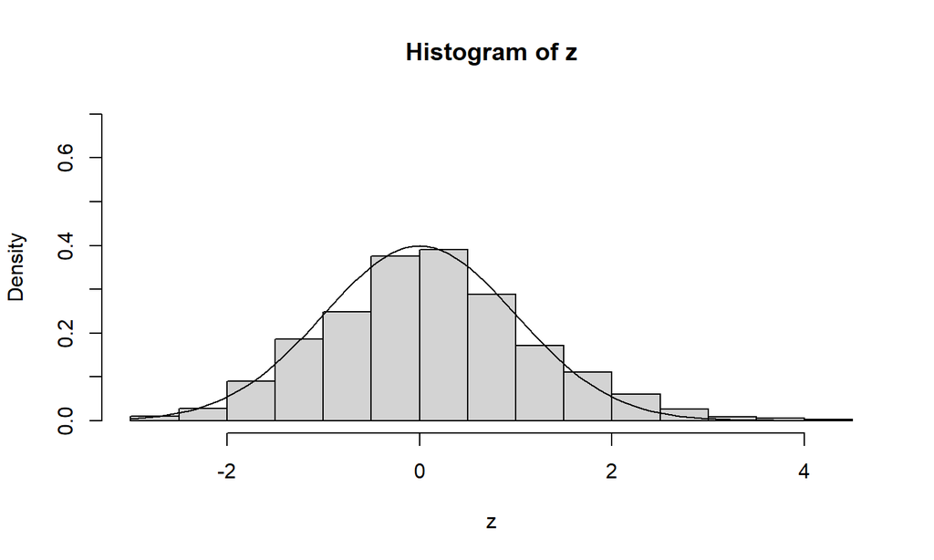

```r
set.seed(123)
n = 1000 ; p1 = 0.05
z1 = rnorm(n*p1, 2, 1); z2 = rnorm(n*(1-p1),0, 1)
z = c(z1,z2)
hist(z, freq = F, ylim = c(0,0.7)); curve(dnorm, add = T)
```

## Testing

Suppose, \(H_0: \mu = 0\) vs. \(H_1: \mu \ne 0\) (Simple \(Z\)-test)

```r
rawp = 2*(1 - pnorm(abs(z)))
reject.indices <- 1*(rawp < 0.05)
sum(reject.indices)
```

```
## [1] 75
```

```r
true.indices = c(rep(1, n*p1), rep(0, n*(1-p1)))

(table(true.indices,reject.indices))
```

```
##             reject.indices
## true.indices   0   1
##            0 899  51
##            1  26  24
```

```r
cat("number of false discoveries", sum((true.indices==0)&(reject.indices==1)))
```

```
## number of false discoveries 51
```

## False rejection

- Naively comparing all \(n\) P-values to the significance level \(\alpha\) would mean that by purely random chance, \(n \times \alpha\) of them will be falsely rejected.
- Why?

## False Discoveries

- Under the \(H_0\), p-values are (1-CDF)’s, i.e. each \(p_i \sim U(0,1)\), i.e. \(P(p_i \le \alpha) = \alpha\).
- Probability of error = \(\alpha\), Probability of not making an error = \(1-\alpha\).
- Probability of not making an error in \(m\) tests: \((1-\alpha)^m\).
- P(Making at least 1 error in \(m\) tests) = \(1-(1-\alpha)^m\).
- P(Making at least 1 error in \(m\) tests) is also called familywise error probability (FWEP).

## How does this grow with \(m\)?

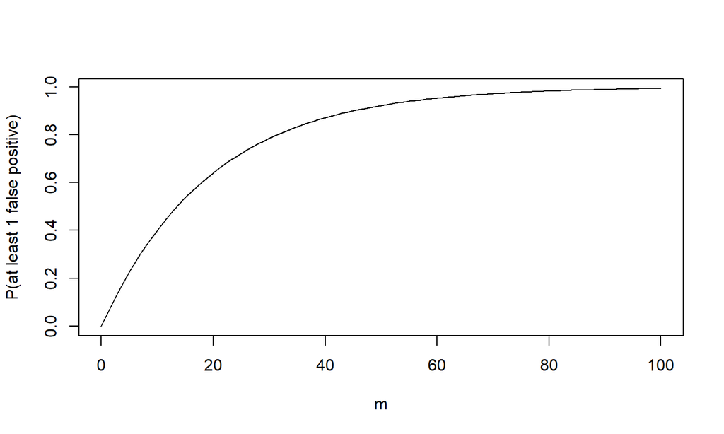

```r
m = (0:100)
alpha = 0.05
FWEP = 1 - (1-alpha)^m
plot(m,FWEP,type = "l", ylab = "P(at least 1 false positive)")
```

## Example from Prostate Cancer

- We will read the prostate cancer dataset from this website: http://statweb.stanford.edu/~ckirby/brad/LSI/datasets-and-programs/datasets.html.
- This data-set has gene expression values for \(6,033\) genes for 50 normal and 52 cancer patients (total 102 columns): labeled 1 and 2 for control and treatment.
- Question: which genes are important?

## Load data

**Read the instructions carefully*

- The datasets are RData files, with extension .RData. They need to be loaded into R using the “load” command.
- To use alpha, for example, right-click on the link and select “Save link as…”, which will open a dialog on your computer prompting you to save the file. Then load it in R with

```r
load('prostatedata.RData')
```

## Dimensions

- As expected, this data-set has 6033 genes and 102 columns.

```r
dim(prostatedata)
```

```
## [1] 6033  102
```

- How do we find out which genes are important?
- Multiple testing !!

## Many, many tests

- We want to carry out a hypothesis test for each gene, i.e. total 6,033 tests
- \(H_{0i}\): i-th gene is not important.
- \(H_{1i}\): i-th gene is important.
- This is equivalent to testing
- \(H_{0i}\): \(\mu_{1i} = \mu_{2i}\), where \(\mu_1\), \(\mu_2\) are centers for groups 1 and 2.
- \(H_{1i}\): \(\mu_{1i} \ne \mu_{2i}\), where \(\mu_1\), \(\mu_2\) are centers for groups 1 and 2.

## Many, many tests

- Let’s do a t-test for each gene. (R code below)

```r
prostate_pvals = numeric(6033) ## empty vectors
prostate_tvals = numeric(6033)

for(i in 1:6033){
  t_test <-  t.test(prostatedata[i,1:50],prostatedata[i,51:102],
                    paired = FALSE, var.equal = FALSE)
  prostate_pvals[i] <-  t_test$p.value
  prostate_tvals[i] <- t_test$statistic
}
```

## Why t-test?

- You can do any tests for each gene e.g., two-sample t-test, **Wilcoxon rank-sum** test, Mann-Whitney test, for each row of a data frame.
- Should we use a t-test or a different test?
- How do you know?

## Visualize

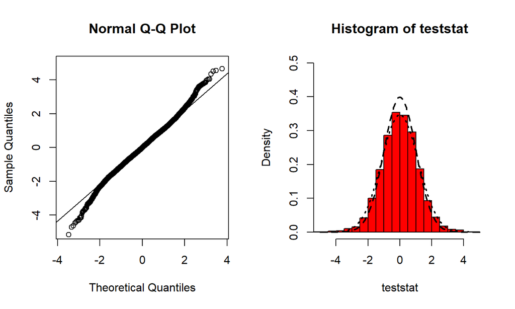

- Histogram and N(0,1) density slightly different - a few interesting genes?

## Multiple Testing Issues

- We have a large number of tests: 6033. If we use standard hypothesis testing at a 5% significance level, 5% of all tests will be falsely rejected (type 1 error) just by pure chance.
- We need some kind of multiplicity control.
- The most stringent is Bonferroni: Divide each \(\alpha\) by the total number of tests \(p = 6033\).

## Bonferroni

- Bonferroni’s correction controls for the familywise error rate (FWER) instead of each \(\alpha\). \[ FWER = P(\text{at least one false rejection}) \le \alpha \]
- Bonferroni leads to a stringent test, since \(\alpha/p\) could be very small if we are carrying out a large number of \(p\) tests simultaneously.
- In R, we can apply the `p.adjust` function for this task.
- `p.adjust` also has other useful methods such as “Benjamini-Hochberg False Discovery Rate control procedure”.

## Bonferroni

- \(M\) hypothesis tests: \(H_{0m}\) vs. \(H_{1m}\) for \(m = 1, \ldots, M\).
- Let \(p_1, \ldots, p_M\) be the p-values for these \(M\) tests.
- In our case \(M = p\) (no. of genes)
- Bonferroni method: \[ \text{Reject null hypothesis } H_{0m} \text{ if } p_m \le \frac{\alpha}{M} \]
- Outcome: The probability of falsely rejecting any null hypothesis is less than or equal to \(\alpha\).

## Histograms of p-values

- **What does this tell you?**

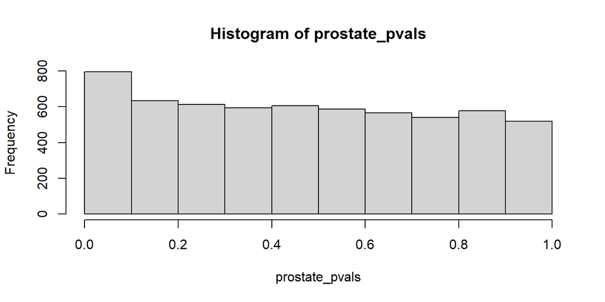

- Many small P-values, there might be a few significant genes.

## Further Analysis

- If we simply reject all genes with p-values less than \(0.05\) we get too many !

```r
sum(prostate_pvals<0.05)
```

```
## [1] 478
```

- Let’s try Bonferroni correction !

## Enter Bonferroni

```r
rawp = prostate_pvals
selected  <- p.adjust(rawp, method = "bonferroni") <0.05
sum(selected)
```

```
## [1] 2
```

- Bonferroni’s correction leads to rejection of 2 tests !!
- Too few !!

## Solution

- The solution to selecting too few genes is to choose a different multiple testing strategy that is less conservative.
- To do this we have to slightly modify what we want to control.
- It turns out that we can control the proportion of false rejections to achieve this.
- This is called Benjamini–Hochberg multiple testing procedure.

## Benjamini-Hochberg

- Let \(M_0\) be the number of null hypotheses that are true, \(M_0 = M - M_1\).

|  | \(H_0\) acc | \(H_0\) rej | Total |
| --- | --- | --- | --- |
| \(H_0\) true | U | V | \(M_0\) |
| \(H_0\) false | T | S | \(M_1\) |
| Total | M-R | R | \(M\) |

Define the false discovery proportion (FDP): \[ FDP = \begin{cases} V/R \text{ if } R > 0 \\ 0 \text { otherwise} \end{cases} \]

## Benjamini-Hochberg

- \(M\) hypothesis tests We order the p-values in increasing order. \(p_{(1)} \le \ldots \le p_{(M)}\).
- *Benjamini-Hochberg Method*
  1. For a given \(\alpha\) find the largest \(k\) such that \[ p_{(k)} \le k \frac{\alpha}{M} \]
  2. Then reject all \(H_{0m}\) for \(m = 1, \ldots, k\).
- *Theorem* : \[ FDR = E(FDP) \le \frac{M_0}{M}\alpha \le \alpha \]
- *Outcome*: For a given significance level \(\alpha\), the Benjamini Hochberg method bounds the false discovery rate.

## Benjamini-Hochberg

- The same R function `p.adjust` can apply the Benjamin-Hochberg correction with just one single change: “BH” instead of “bonferroni” as argument.

```r
rawp = prostate_pvals
selected  <- p.adjust(rawp, method = "BH") <0.05
sum(selected)
```

```
## [1] 21
```

- Benjamini-Hochberg method leads to rejection of 21 tests - less stringent than Bonferroni.

## Project tasks

1. Which non-parametric tests are suitable for this problem?
2. Apply the tests you think are suitable and obtain a large vector of p-values, then use `p.adjust` to apply both the Bonferroni and Benjamini-Hochberg tests.
3. What happens when you don’t apply any multiplicity correction?

## A caution

- There are many different ways of doing the same analysis - we usually pick the one that gives us a reasonably accurate and yet meaningful answer.
- In real data, unlike in our numerical experiments, there is no ground truth !
- For example, in a Statistical genetics study, your collaborator (a geneticist) might have some prior biological knowledge about which genes should be different, and that provides a way of checking validity.

## Project 2: Test of Association for Political Data

## Project 2: Contingency tables

- Some of the best examples of contingency tables come from Political data analysis.
- Example: Analyzing Exit Poll Data from CNN. Total number of respondents = 24537.

| Party | 18-24 | 25-29 | 30-39 | 40-49 | 50-64 | 65 and older |
| --- | --- | --- | --- | --- | --- | --- |
| Clinton | 56% | 53% | 51% | 46% | 44% | 45% |
| Trump | 35% | 39% | 40% | 50% | 53% | 53% |

## Test for association

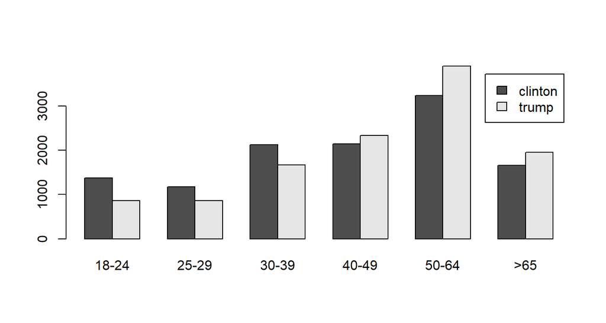

```r
clinton = c(1374,1170,2127,2145,3239,1656)
trump = c(859,861,1669,2331,3901,1951)
elect16= rbind(clinton,trump)
dimnames(elect16) = list(candidate = c("clinton","trump"),
                         agegp = c("18-24","25-29","30-39",
                                   "40-49","50-64",">65"))
barplot(elect16, beside=T, legend=T)
```

## Chi-square test

```r
chisq.test(elect16)
```

```
##
##  Pearson's Chi-squared test
##
## data:  elect16
## X-squared = 313.46, df = 5, p-value < 2.2e-16
```

## Effect of Gender?

- We can also look at the effect of Gender!
- The same CNN exit poll data : 24537 respondents.

| Party | clinton | trump | others |
| --- | --- | --- | --- |
| male | 41% | 53% | 6% |
| female | 54% | 42% | 4% |

## Use R

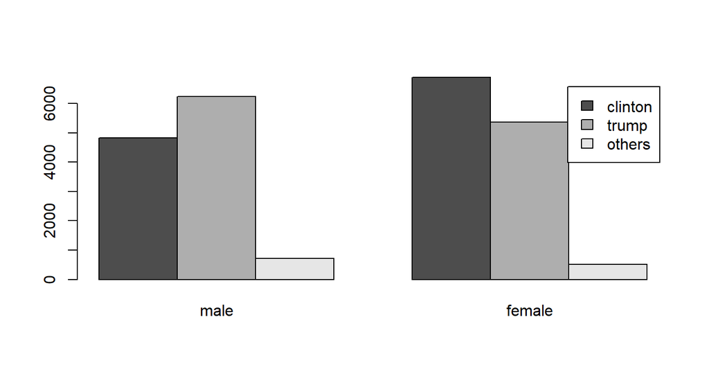

```r
gender <- matrix(c(4829,6242,707,6890,5359,510), byrow = T, ncol = 3)
dimnames(gender) = list(gender = c("male","female"),
                        candidate = c("clinton","trump","others"))
barplot(t(gender), beside=T, legend=T)
```

## Chi-square test of association

```r
gender <- matrix(c(4829,6242,707,6890,5359,510), byrow = T, ncol = 3)
dimnames(gender) = list(gender = c("male","female"),
                        candidate = c("clinton","trump","others"))
prop.table(gender, 1)
```

```
##         candidate
## gender     clinton     trump     others
##   male   0.4100017 0.5299711 0.06002717
##   female 0.5400110 0.4200172 0.03997178
```

```r
chisq.test(gender)
```

```
##
##  Pearson's Chi-squared test
##
## data:  gender
## X-squared = 423.02, df = 2, p-value < 2.2e-16
```

## Data source

Get the 2016 exit poll data from this CNN webpage:

https://www.cnn.com/election/2016/results/exit-polls.

and the 2020 exit poll data from another CNN webpage:

https://www.cnn.com/election/2020/exit-polls/president/national-results.

## Project goals

1. Which variables are interesting or important?
- National or state-wise? Are the patterns different?
- Education / Ideology / Religion
1. Can you identify at least one way in which the 2016 associations differed from 2020 associations based on the above data?
2. Can you also comment on why these results might differ from the ground reality?